# Meiofauna and Macrofauna Biomass-Size Composition

Chih-Lin Wei

2023-02-26

```r
library(bbbs)
library(ggplot2)
library(ggrepel)
library(plyr)
library(doBy)
library(readxl)
library(reshape2)
library(vegan)
library(RColorBrewer)
library(metR)
library(knitr)
library(viridis)
library(ggdendro)

large <- theme(legend.title = element_text(size=20),
        legend.text = element_text(size=20),
        axis.title = element_text(size=20),
        axis.text = element_text(size=20))

rotate <- theme(axis.text.x = element_text(size=20, angle=60, hjust=0.5))
no_legend <- theme(legend.position = "none")

# dark theme for ggplot
dark <- theme(plot.background = element_rect(colour = 'NA', fill = 'gray10'),
        panel.background = element_rect(colour = 'NA', fill = 'transparent'),
        legend.background = element_rect(colour = 'NA', fill = 'transparent'),
        legend.title = element_text(colour = 'white', size=20),
        legend.text = element_text(colour = 'white', size=20),
        axis.title = element_text(colour = 'white', size=20),
        axis.text = element_text(colour = 'white', size=20),
        axis.ticks = element_line(colour = 'white'),
        panel.border = element_rect(fill = 'NA', colour = 'white'),
        panel.grid.major = element_line(colour = 'gray30'),
        panel.grid.minor = element_line(colour = 'gray20'))

jet.colors <-
  colorRampPalette(c("#00007F", "blue", "#007FFF", "cyan",
                     "#7FFF7F", "yellow", "#FF7F00", "red", "#7F0000"))

# log2 bin
l2b <- function(x) 2^( floor(log2(min(x))) : ceiling(log2(max(x))) )

bks <- l2b(c(mei_s$Wt, mac_s$Wt))
```

# 1 Correlation among environmental factors

Temperature, salinity, dissolved oxygen concentration, fluorescence, and light transmission of the bottom water were measured by a conductivity-temperature-depth (CTD) recorder (Sea-Bird SBE 911) and other attached sensors. Surface sediment grain sizes (non-carbonate fraction) were measured by a laser diffraction particle size analyzer (Beckman Coulter LS13 320). Total organic carbon (TOC) and total nitrogen (TN) were analyzed with a Flash EA 1112 elemental analyzer. Porosity was estimated from wet weight and dry weight of sediment and assuming the dry sediment density of 2.65 g/cm3. Hourly bottom current velocity at each site was derived from a 3-D, hydrodynamic internal tide model from Chiou et al. (2011). Based on the internal tide model, we calculated the hourly mean velocity of bottom currents and the duration for which bottom current velocity exceeded 20 cm/s for 1 month preceding the sampling campaign to evaluate the possible disturbances of near-bottom currents on nematodes.

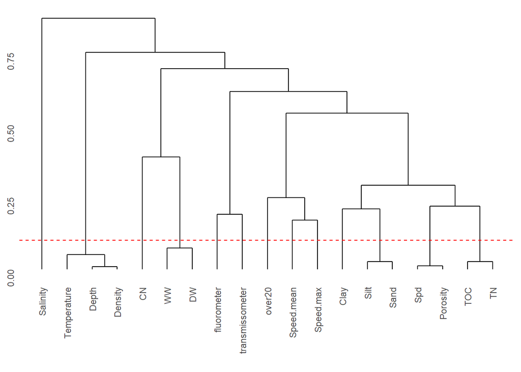

```r
# Normalized enivronmental data to mean zero and unit variance
es <- as.data.frame(scale(env[, c(-1:-6, -11, -14)]))
names(es)[13] <- "Spd"
# Calculate absolute correlation coefficient
co <- as.dist(matrix(1, nrow=19, ncol=19)-abs(cor(es, use="pairwise.complete.obs")))
hc <- hclust(co, method="average")

# Convert dendrogram to ggplot style
dhc <- as.dendrogram(hc)
ghc    <- dendro_data(dhc, type="rectangle")

ggdendrogram(hc, rotate = FALSE)+
  geom_hline(yintercept=0.1, linetype=2, colour="red")
```

```r
env$Strata <- cut(env$Depth, breaks=c(200, 400, 600, 800, 1100), labels=c("200-400", "400-600", "600-800", "800-1100"))
```

To avoid auto-correlations, redundant environmental variables (correlations > 0.9) were removed. For example, the bottom water temperature, density, and dissolved oxygen measured in this study were highly correlated. Therefore, the dissolved oxygen was not retained because the bottom dissolved oxygen concentration never dropped below the threshold of hypoxia (2 mg/L), presumably, due to turbulence mixing by internal tides. The density was not retained because it’s not an important factor known to affect infauna assemblages. Only the ecologically relevant variables, including bottom water temperature, salinity, light transmission, percent sand, silt and clay, sediment TOC and C/N ratio, porosity, mean bottom current velocity, and duration of bottom current velocity exceeding 20 cm/s were retained for the analysis. These variables were logarithm (base of 10) transformed, centered (subtracted from the mean), and normalized (divided by the standard deviation) prior to use in statistical analyses involving environmental variables.